| 가계동향조사(2019년~)_연간자료(지출, 2019~) - 전체가구_1인이상(제공)_2019_수정 |  | 생성일자 : 2020년 08월 25일 12시 38분 00초 |
| --- | --- | --- |
| **분석방법** | 회귀분석 |  |
| **반응항목** | 소비지출 |  |
| **설명항목** | 가구원수/취업인원수 |  |
| **추가분석** | 상관계수/회귀진단 |  |

#### 분산분석표

[interactive chart not shown]

##### ♦ 회귀모형에 대한 설명 정도를 나타내는 결정계수(R-Square)는 0.2702입니다. ♦ 분산분석표에서 일반적으로 유의수준 5%로 검정하는 경우 유의확률이 0.05이하이면 귀무가설을 기각하게 되어 설정된 회귀모형이 적합하다고 할 수 있습니다.

#### 회귀계수 추정

[interactive chart not shown]

##### ♦ 회귀계수 추정은 설정된 모형에 대한 설명 항목별 회귀계수를 추정하고, 이에 대한 유의성을 검정할 수 있습니다. ♦ 유의수준 5%로 검정하는 경우 유의확률이 0.05이하이면 귀무가설을 기각하게 되어 해당 설명 항목의 회귀계수가 유의하다고 할 수 있습니다. ♦ 추정된 회귀방정식은 '소비지출 = 578,830.516 + 637,956.284*(가구원수) + 264,234.619*(취업인원수)' 입니다.

#### 상관행렬

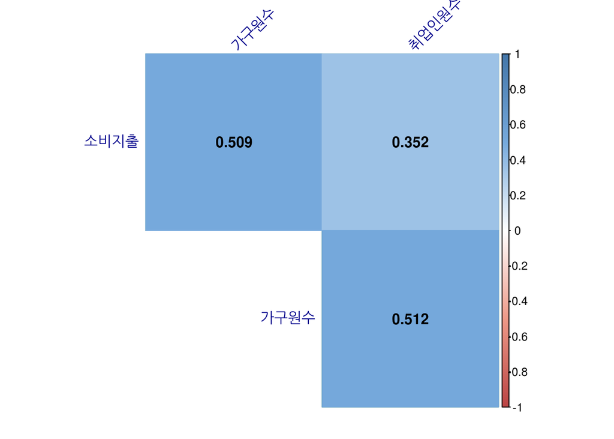

##### ♦ 상관행렬은 선택된 반응/설명 항목간의 상관계수를 그래프 형태로 제공합니다. ♦ 수치는 두 분석 항목간의 상관계수를 나타내며, '-1과 1에 가까울 수록 상관의 정도가 크고 0에 가까울 수록 상관의 정도가 작은것'을 의미합니다. ♦ 수치에 X표시는 유의수준 5%하에서 두 항목간의 상관이 없음을 의미합니다.

#### 회귀진단

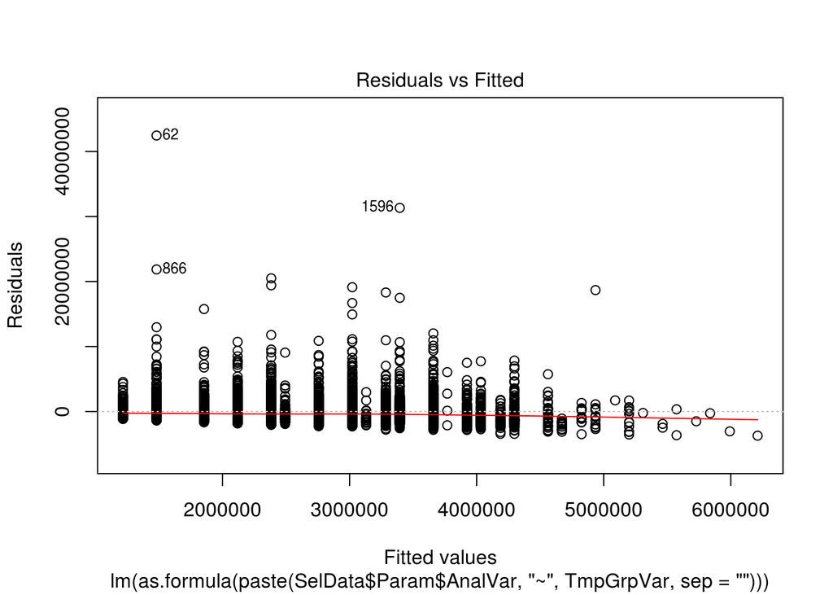

##### ♦ 회귀진단은 설정된 모형의 잔차에 대한 가정검토 및 모형에 영향을 미치는 이상치 분석을 그래프로 제공합니다.